# Risk Factor Analysis

## Outcome Variable

**Outcome Variable:** haz

## Predictor Variables

**Intervention Variable:** predfeed36

**Adjustment Set:**

unadjusted

## Stratifying Variables

The analysis was stratified on these variable(s):

- agecat
- studyid
- country

## Data Summary

| agecat | studyid | country | predfeed36 | n_cell | n |
| --- | --- | --- | --- | --- | --- |
| Birth | ki0047075b-MAL-ED | BANGLADESH | 1 | 125 | 243 |
| Birth | ki0047075b-MAL-ED | BANGLADESH | 0 | 118 | 243 |
| Birth | ki0047075b-MAL-ED | BRAZIL | 1 | 29 | 185 |
| Birth | ki0047075b-MAL-ED | BRAZIL | 0 | 156 | 185 |
| Birth | ki0047075b-MAL-ED | INDIA | 1 | 16 | 198 |
| Birth | ki0047075b-MAL-ED | INDIA | 0 | 182 | 198 |
| Birth | ki0047075b-MAL-ED | NEPAL | 1 | 26 | 172 |
| Birth | ki0047075b-MAL-ED | NEPAL | 0 | 146 | 172 |
| Birth | ki0047075b-MAL-ED | PERU | 1 | 118 | 273 |
| Birth | ki0047075b-MAL-ED | PERU | 0 | 155 | 273 |
| Birth | ki0047075b-MAL-ED | SOUTH AFRICA | 1 | 3 | 236 |
| Birth | ki0047075b-MAL-ED | SOUTH AFRICA | 0 | 233 | 236 |
| Birth | ki0047075b-MAL-ED | TANZANIA, UNITED REPUBLIC OF | 1 | 1 | 121 |
| Birth | ki0047075b-MAL-ED | TANZANIA, UNITED REPUBLIC OF | 0 | 120 | 121 |
| Birth | ki1000109-EE | PAKISTAN | 1 | 1 | 2 |
| Birth | ki1000109-EE | PAKISTAN | 0 | 1 | 2 |
| Birth | kiGH5241-JiVitA-3 | BANGLADESH | 1 | 11176 | 13946 |
| Birth | kiGH5241-JiVitA-3 | BANGLADESH | 0 | 2770 | 13946 |
| Birth | kiGH5241-JiVitA-4 | BANGLADESH | 1 | 582 | 727 |
| Birth | kiGH5241-JiVitA-4 | BANGLADESH | 0 | 145 | 727 |
| 6 months | ki0047075b-MAL-ED | BANGLADESH | 1 | 129 | 240 |
| 6 months | ki0047075b-MAL-ED | BANGLADESH | 0 | 111 | 240 |
| 6 months | ki0047075b-MAL-ED | BRAZIL | 1 | 37 | 209 |
| 6 months | ki0047075b-MAL-ED | BRAZIL | 0 | 172 | 209 |
| 6 months | ki0047075b-MAL-ED | INDIA | 1 | 19 | 236 |
| 6 months | ki0047075b-MAL-ED | INDIA | 0 | 217 | 236 |
| 6 months | ki0047075b-MAL-ED | NEPAL | 1 | 32 | 236 |
| 6 months | ki0047075b-MAL-ED | NEPAL | 0 | 204 | 236 |
| 6 months | ki0047075b-MAL-ED | PERU | 1 | 126 | 271 |
| 6 months | ki0047075b-MAL-ED | PERU | 0 | 145 | 271 |
| 6 months | ki0047075b-MAL-ED | SOUTH AFRICA | 1 | 3 | 254 |
| 6 months | ki0047075b-MAL-ED | SOUTH AFRICA | 0 | 251 | 254 |
| 6 months | ki0047075b-MAL-ED | TANZANIA, UNITED REPUBLIC OF | 1 | 2 | 247 |
| 6 months | ki0047075b-MAL-ED | TANZANIA, UNITED REPUBLIC OF | 0 | 245 | 247 |
| 6 months | ki1000109-EE | PAKISTAN | 1 | 222 | 367 |
| 6 months | ki1000109-EE | PAKISTAN | 0 | 145 | 367 |
| 6 months | ki1000304b-SAS-FoodSuppl | INDIA | 1 | 0 | 168 |
| 6 months | ki1000304b-SAS-FoodSuppl | INDIA | 0 | 168 | 168 |
| 6 months | ki1113344-GMS-Nepal | NEPAL | 1 | 423 | 526 |
| 6 months | ki1113344-GMS-Nepal | NEPAL | 0 | 103 | 526 |
| 6 months | ki1148112-LCNI-5 | MALAWI | 1 | 47 | 272 |
| 6 months | ki1148112-LCNI-5 | MALAWI | 0 | 225 | 272 |
| 6 months | kiGH5241-JiVitA-3 | BANGLADESH | 1 | 10705 | 13375 |
| 6 months | kiGH5241-JiVitA-3 | BANGLADESH | 0 | 2670 | 13375 |
| 6 months | kiGH5241-JiVitA-4 | BANGLADESH | 1 | 3256 | 4171 |
| 6 months | kiGH5241-JiVitA-4 | BANGLADESH | 0 | 915 | 4171 |
| 24 months | ki0047075b-MAL-ED | BANGLADESH | 1 | 117 | 211 |
| 24 months | ki0047075b-MAL-ED | BANGLADESH | 0 | 94 | 211 |
| 24 months | ki0047075b-MAL-ED | BRAZIL | 1 | 30 | 169 |
| 24 months | ki0047075b-MAL-ED | BRAZIL | 0 | 139 | 169 |
| 24 months | ki0047075b-MAL-ED | INDIA | 1 | 18 | 227 |
| 24 months | ki0047075b-MAL-ED | INDIA | 0 | 209 | 227 |
| 24 months | ki0047075b-MAL-ED | NEPAL | 1 | 30 | 228 |
| 24 months | ki0047075b-MAL-ED | NEPAL | 0 | 198 | 228 |
| 24 months | ki0047075b-MAL-ED | PERU | 1 | 94 | 200 |
| 24 months | ki0047075b-MAL-ED | PERU | 0 | 106 | 200 |
| 24 months | ki0047075b-MAL-ED | SOUTH AFRICA | 1 | 3 | 238 |
| 24 months | ki0047075b-MAL-ED | SOUTH AFRICA | 0 | 235 | 238 |
| 24 months | ki0047075b-MAL-ED | TANZANIA, UNITED REPUBLIC OF | 1 | 2 | 214 |
| 24 months | ki0047075b-MAL-ED | TANZANIA, UNITED REPUBLIC OF | 0 | 212 | 214 |
| 24 months | ki1113344-GMS-Nepal | NEPAL | 1 | 369 | 456 |
| 24 months | ki1113344-GMS-Nepal | NEPAL | 0 | 87 | 456 |
| 24 months | ki1148112-LCNI-5 | MALAWI | 1 | 34 | 189 |
| 24 months | ki1148112-LCNI-5 | MALAWI | 0 | 155 | 189 |
| 24 months | kiGH5241-JiVitA-3 | BANGLADESH | 1 | 5293 | 6693 |
| 24 months | kiGH5241-JiVitA-3 | BANGLADESH | 0 | 1400 | 6693 |
| 24 months | kiGH5241-JiVitA-4 | BANGLADESH | 1 | 3153 | 4023 |
| 24 months | kiGH5241-JiVitA-4 | BANGLADESH | 0 | 870 | 4023 |

The following strata were considered:

- agecat: 24 months, studyid: ki0047075b-MAL-ED, country: BANGLADESH
- agecat: 24 months, studyid: ki0047075b-MAL-ED, country: BRAZIL
- agecat: 24 months, studyid: ki0047075b-MAL-ED, country: INDIA
- agecat: 24 months, studyid: ki0047075b-MAL-ED, country: NEPAL
- agecat: 24 months, studyid: ki0047075b-MAL-ED, country: PERU
- agecat: 24 months, studyid: ki0047075b-MAL-ED, country: SOUTH AFRICA
- agecat: 24 months, studyid: ki0047075b-MAL-ED, country: TANZANIA, UNITED REPUBLIC OF
- agecat: 24 months, studyid: ki1113344-GMS-Nepal, country: NEPAL
- agecat: 24 months, studyid: ki1148112-LCNI-5, country: MALAWI
- agecat: 24 months, studyid: kiGH5241-JiVitA-3, country: BANGLADESH
- agecat: 24 months, studyid: kiGH5241-JiVitA-4, country: BANGLADESH
- agecat: 6 months, studyid: ki0047075b-MAL-ED, country: BANGLADESH
- agecat: 6 months, studyid: ki0047075b-MAL-ED, country: BRAZIL
- agecat: 6 months, studyid: ki0047075b-MAL-ED, country: INDIA
- agecat: 6 months, studyid: ki0047075b-MAL-ED, country: NEPAL
- agecat: 6 months, studyid: ki0047075b-MAL-ED, country: PERU
- agecat: 6 months, studyid: ki0047075b-MAL-ED, country: SOUTH AFRICA
- agecat: 6 months, studyid: ki0047075b-MAL-ED, country: TANZANIA, UNITED REPUBLIC OF
- agecat: 6 months, studyid: ki1000109-EE, country: PAKISTAN
- agecat: 6 months, studyid: ki1000304b-SAS-FoodSuppl, country: INDIA
- agecat: 6 months, studyid: ki1113344-GMS-Nepal, country: NEPAL
- agecat: 6 months, studyid: ki1148112-LCNI-5, country: MALAWI
- agecat: 6 months, studyid: kiGH5241-JiVitA-3, country: BANGLADESH
- agecat: 6 months, studyid: kiGH5241-JiVitA-4, country: BANGLADESH
- agecat: Birth, studyid: ki0047075b-MAL-ED, country: BANGLADESH
- agecat: Birth, studyid: ki0047075b-MAL-ED, country: BRAZIL
- agecat: Birth, studyid: ki0047075b-MAL-ED, country: INDIA
- agecat: Birth, studyid: ki0047075b-MAL-ED, country: NEPAL
- agecat: Birth, studyid: ki0047075b-MAL-ED, country: PERU
- agecat: Birth, studyid: ki0047075b-MAL-ED, country: SOUTH AFRICA
- agecat: Birth, studyid: ki0047075b-MAL-ED, country: TANZANIA, UNITED REPUBLIC OF
- agecat: Birth, studyid: ki1000109-EE, country: PAKISTAN
- agecat: Birth, studyid: kiGH5241-JiVitA-3, country: BANGLADESH
- agecat: Birth, studyid: kiGH5241-JiVitA-4, country: BANGLADESH

### Dropped Strata

Some strata were dropped due to rare outcomes:

- agecat: Birth, studyid: ki0047075b-MAL-ED, country: SOUTH AFRICA
- agecat: Birth, studyid: ki0047075b-MAL-ED, country: TANZANIA, UNITED REPUBLIC OF
- agecat: Birth, studyid: ki1000109-EE, country: PAKISTAN
- agecat: 6 months, studyid: ki0047075b-MAL-ED, country: SOUTH AFRICA
- agecat: 6 months, studyid: ki0047075b-MAL-ED, country: TANZANIA, UNITED REPUBLIC OF
- agecat: 6 months, studyid: ki1000304b-SAS-FoodSuppl, country: INDIA
- agecat: 24 months, studyid: ki0047075b-MAL-ED, country: SOUTH AFRICA
- agecat: 24 months, studyid: ki0047075b-MAL-ED, country: TANZANIA, UNITED REPUBLIC OF

## Methods Detail

We’re interested in the causal parameters $E[Y_a]$ for all values of $a \in \mathcal{A}$. These parameters represent the mean outcome if, possibly contrary to fact, we intervened to set all units to have $A=a$. Under the randomization and positivity assumptions, these are identified by the statistical parameters $\psi_a=E_W[E_{Y|A,W}(Y|A=a,W)]$. In addition, we’re interested in the mean of $Y$, $E[Y]$ under no intervention (the observed mean). We will estimate these parameters by using SuperLearner to fit the relevant likelihood factors – $E_{Y|A,W}(Y|A=a,W)$ and $p(A=a|W)$, and then updating our likelihood fit using a joint TMLE.

For unadjusted analyses ($W=\{\}$), initial likelihoods were estimated using Lrnr_glm to estimate the simple $E(Y|A)$ and Lrnr_mean to estimate $p(A)$. For adjusted analyses, a small library containing Lrnr_glmnet, Lrnr_xgboost, and Lrnr_mean was used.

Having estimated these parameters, we will then use the delta method to estimate relative risks and attributable risks relative to a prespecified baseline level of $A$.

# Results Detail

## Results Plots

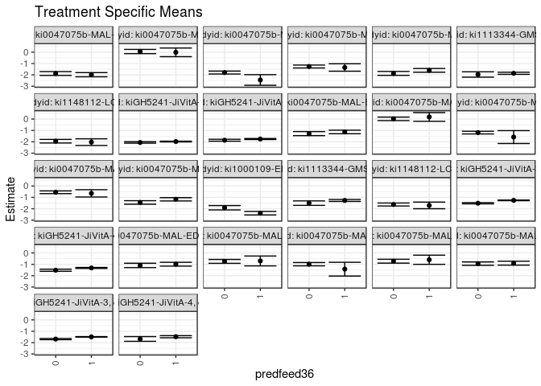

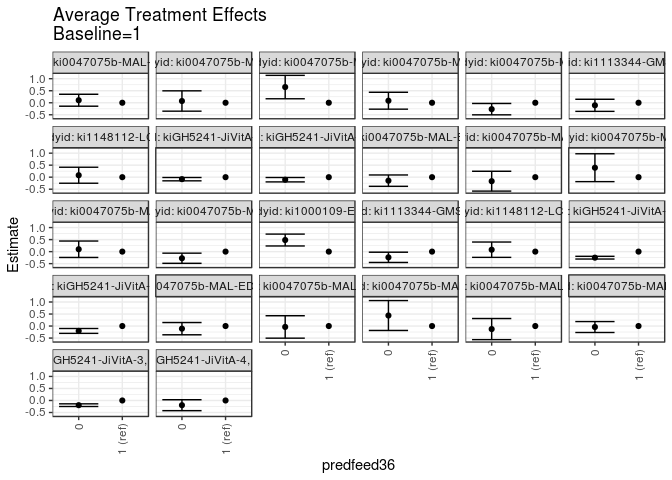

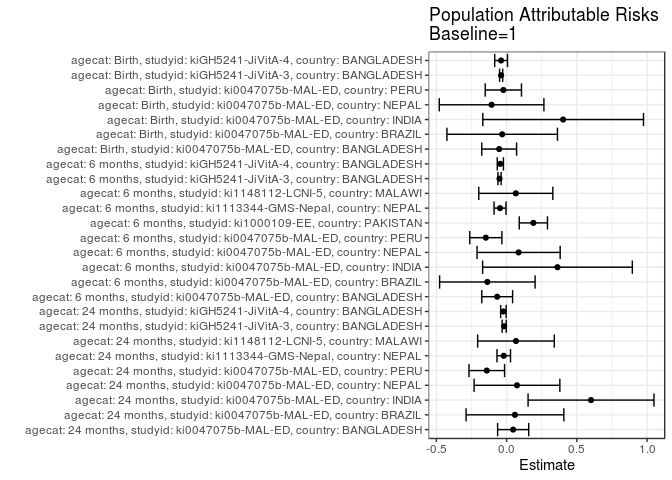

## Results Table

### Parameter: TSM

| agecat | studyid | country | intervention_level | baseline_level | estimate | ci_lower | ci_upper |
| --- | --- | --- | --- | --- | --- | --- | --- |
| Birth | ki0047075b-MAL-ED | BANGLADESH | 1 | NA | -0.9886400 | -1.1565669 | -0.8207131 |
| Birth | ki0047075b-MAL-ED | BANGLADESH | 0 | NA | -1.0974576 | -1.2894047 | -0.9055105 |
| Birth | ki0047075b-MAL-ED | BRAZIL | 1 | NA | -0.7037931 | -1.1379937 | -0.2695925 |
| Birth | ki0047075b-MAL-ED | BRAZIL | 0 | NA | -0.7408974 | -0.9116664 | -0.5701284 |
| Birth | ki0047075b-MAL-ED | INDIA | 1 | NA | -1.4262500 | -2.0314939 | -0.8210061 |
| Birth | ki0047075b-MAL-ED | INDIA | 0 | NA | -0.9881319 | -1.1322306 | -0.8440331 |
| Birth | ki0047075b-MAL-ED | NEPAL | 1 | NA | -0.5984615 | -1.0026795 | -0.1942436 |
| Birth | ki0047075b-MAL-ED | NEPAL | 0 | NA | -0.7243151 | -0.8950910 | -0.5535391 |
| Birth | ki0047075b-MAL-ED | PERU | 1 | NA | -0.9000847 | -1.0719525 | -0.7282170 |
| Birth | ki0047075b-MAL-ED | PERU | 0 | NA | -0.9406452 | -1.0892360 | -0.7920543 |
| Birth | kiGH5241-JiVitA-3 | BANGLADESH | 1 | NA | -1.4944613 | -1.5182421 | -1.4706806 |
| Birth | kiGH5241-JiVitA-3 | BANGLADESH | 0 | NA | -1.6903430 | -1.7413156 | -1.6393703 |
| Birth | kiGH5241-JiVitA-4 | BANGLADESH | 1 | NA | -1.4808591 | -1.5746857 | -1.3870325 |
| Birth | kiGH5241-JiVitA-4 | BANGLADESH | 0 | NA | -1.6774483 | -1.8860140 | -1.4688825 |
| 6 months | ki0047075b-MAL-ED | BANGLADESH | 1 | NA | -1.1337080 | -1.2886597 | -0.9787564 |
| 6 months | ki0047075b-MAL-ED | BANGLADESH | 0 | NA | -1.2785135 | -1.4567834 | -1.1002436 |
| 6 months | ki0047075b-MAL-ED | BRAZIL | 1 | NA | 0.1879730 | -0.1951683 | 0.5711142 |
| 6 months | ki0047075b-MAL-ED | BRAZIL | 0 | NA | 0.0215601 | -0.1324881 | 0.1756083 |
| 6 months | ki0047075b-MAL-ED | INDIA | 1 | NA | -1.5826316 | -2.1499971 | -1.0152660 |
| 6 months | ki0047075b-MAL-ED | INDIA | 0 | NA | -1.1886482 | -1.3065016 | -1.0707949 |
| 6 months | ki0047075b-MAL-ED | NEPAL | 1 | NA | -0.6466146 | -0.9669547 | -0.3262745 |
| 6 months | ki0047075b-MAL-ED | NEPAL | 0 | NA | -0.5476389 | -0.6678808 | -0.4273970 |
| 6 months | ki0047075b-MAL-ED | PERU | 1 | NA | -1.1694444 | -1.3144931 | -1.0243958 |
| 6 months | ki0047075b-MAL-ED | PERU | 0 | NA | -1.4459080 | -1.5998363 | -1.2919798 |
| 6 months | ki1000109-EE | PAKISTAN | 1 | NA | -2.3915090 | -2.5470464 | -2.2359716 |
| 6 months | ki1000109-EE | PAKISTAN | 0 | NA | -1.9091724 | -2.1006572 | -1.7176877 |
| 6 months | ki1113344-GMS-Nepal | NEPAL | 1 | NA | -1.2683964 | -1.3548728 | -1.1819200 |
| 6 months | ki1113344-GMS-Nepal | NEPAL | 0 | NA | -1.5064239 | -1.7019768 | -1.3108711 |
| 6 months | ki1148112-LCNI-5 | MALAWI | 1 | NA | -1.7051064 | -1.9955729 | -1.4146399 |
| 6 months | ki1148112-LCNI-5 | MALAWI | 0 | NA | -1.6259111 | -1.7571663 | -1.4946560 |
| 6 months | kiGH5241-JiVitA-3 | BANGLADESH | 1 | NA | -1.2618748 | -1.2883218 | -1.2354278 |
| 6 months | kiGH5241-JiVitA-3 | BANGLADESH | 0 | NA | -1.5138577 | -1.5669424 | -1.4607729 |
| 6 months | kiGH5241-JiVitA-4 | BANGLADESH | 1 | NA | -1.3157555 | -1.3577626 | -1.2737485 |
| 6 months | kiGH5241-JiVitA-4 | BANGLADESH | 0 | NA | -1.5185410 | -1.6126924 | -1.4243896 |
| 24 months | ki0047075b-MAL-ED | BANGLADESH | 1 | NA | -1.9831197 | -2.1649968 | -1.8012425 |
| 24 months | ki0047075b-MAL-ED | BANGLADESH | 0 | NA | -1.8780851 | -2.0466854 | -1.7094848 |
| 24 months | ki0047075b-MAL-ED | BRAZIL | 1 | NA | -0.0176667 | -0.3977125 | 0.3623792 |
| 24 months | ki0047075b-MAL-ED | BRAZIL | 0 | NA | 0.0546763 | -0.1312815 | 0.2406340 |
| 24 months | ki0047075b-MAL-ED | INDIA | 1 | NA | -2.4469444 | -2.9158076 | -1.9780813 |
| 24 months | ki0047075b-MAL-ED | INDIA | 0 | NA | -1.7940431 | -1.9224573 | -1.6656289 |
| 24 months | ki0047075b-MAL-ED | NEPAL | 1 | NA | -1.3491667 | -1.6760825 | -1.0222508 |
| 24 months | ki0047075b-MAL-ED | NEPAL | 0 | NA | -1.2640152 | -1.3932616 | -1.1347687 |
| 24 months | ki0047075b-MAL-ED | PERU | 1 | NA | -1.6018617 | -1.7650598 | -1.4386637 |
| 24 months | ki0047075b-MAL-ED | PERU | 0 | NA | -1.8681604 | -2.0393662 | -1.6969546 |
| 24 months | ki1113344-GMS-Nepal | NEPAL | 1 | NA | -1.8583198 | -1.9507820 | -1.7658576 |
| 24 months | ki1113344-GMS-Nepal | NEPAL | 0 | NA | -1.9643870 | -2.1983018 | -1.7304722 |
| 24 months | ki1148112-LCNI-5 | MALAWI | 1 | NA | -2.0273529 | -2.3204751 | -1.7342307 |
| 24 months | ki1148112-LCNI-5 | MALAWI | 0 | NA | -1.9459355 | -2.1034386 | -1.7884323 |
| 24 months | kiGH5241-JiVitA-3 | BANGLADESH | 1 | NA | -1.9775043 | -2.0096237 | -1.9453848 |
| 24 months | kiGH5241-JiVitA-3 | BANGLADESH | 0 | NA | -2.0593071 | -2.1245488 | -1.9940655 |
| 24 months | kiGH5241-JiVitA-4 | BANGLADESH | 1 | NA | -1.7538725 | -1.7973826 | -1.7103624 |
| 24 months | kiGH5241-JiVitA-4 | BANGLADESH | 0 | NA | -1.8592184 | -1.9427985 | -1.7756383 |

### Parameter: E(Y)

| agecat | studyid | country | intervention_level | baseline_level | estimate | ci_lower | ci_upper |
| --- | --- | --- | --- | --- | --- | --- | --- |
| Birth | ki0047075b-MAL-ED | BANGLADESH | NA | NA | -1.0414815 | -1.1687478 | -0.9142151 |
| Birth | ki0047075b-MAL-ED | BRAZIL | NA | NA | -0.7350811 | -0.8943683 | -0.5757938 |
| Birth | ki0047075b-MAL-ED | INDIA | NA | NA | -1.0235354 | -1.1657122 | -0.8813585 |
| Birth | ki0047075b-MAL-ED | NEPAL | NA | NA | -0.7052907 | -0.8627483 | -0.5478331 |
| Birth | ki0047075b-MAL-ED | PERU | NA | NA | -0.9231136 | -1.0355489 | -0.8106782 |
| Birth | kiGH5241-JiVitA-3 | BANGLADESH | NA | NA | -1.5333680 | -1.5553430 | -1.5113930 |
| Birth | kiGH5241-JiVitA-4 | BANGLADESH | NA | NA | -1.5200688 | -1.6064560 | -1.4336815 |
| 6 months | ki0047075b-MAL-ED | BANGLADESH | NA | NA | -1.2006806 | -1.3182323 | -1.0831288 |
| 6 months | ki0047075b-MAL-ED | BRAZIL | NA | NA | 0.0510207 | -0.0930194 | 0.1950608 |
| 6 months | ki0047075b-MAL-ED | INDIA | NA | NA | -1.2203672 | -1.3387619 | -1.1019726 |
| 6 months | ki0047075b-MAL-ED | NEPAL | NA | NA | -0.5610593 | -0.6737915 | -0.4483272 |
| 6 months | ki0047075b-MAL-ED | PERU | NA | NA | -1.3173678 | -1.4250795 | -1.2096560 |
| 6 months | ki1000109-EE | PAKISTAN | NA | NA | -2.2009401 | -2.3240630 | -2.0778171 |
| 6 months | ki1113344-GMS-Nepal | NEPAL | NA | NA | -1.3150063 | -1.3948049 | -1.2352077 |
| 6 months | ki1148112-LCNI-5 | MALAWI | NA | NA | -1.6395956 | -1.7592633 | -1.5199278 |
| 6 months | kiGH5241-JiVitA-3 | BANGLADESH | NA | NA | -1.3121772 | -1.3366725 | -1.2876819 |
| 6 months | kiGH5241-JiVitA-4 | BANGLADESH | NA | NA | -1.3602409 | -1.3996637 | -1.3208182 |
| 24 months | ki0047075b-MAL-ED | BANGLADESH | NA | NA | -1.9363270 | -2.0622735 | -1.8103806 |
| 24 months | ki0047075b-MAL-ED | BRAZIL | NA | NA | 0.0418343 | -0.1253834 | 0.2090521 |
| 24 months | ki0047075b-MAL-ED | INDIA | NA | NA | -1.8458150 | -1.9718703 | -1.7197596 |
| 24 months | ki0047075b-MAL-ED | NEPAL | NA | NA | -1.2752193 | -1.3954783 | -1.1549603 |
| 24 months | ki0047075b-MAL-ED | PERU | NA | NA | -1.7430000 | -1.8632412 | -1.6227588 |
| 24 months | ki1113344-GMS-Nepal | NEPAL | NA | NA | -1.8785563 | -1.9657607 | -1.7913519 |
| 24 months | ki1148112-LCNI-5 | MALAWI | NA | NA | -1.9605820 | -2.1001715 | -1.8209925 |
| 24 months | kiGH5241-JiVitA-3 | BANGLADESH | NA | NA | -1.9946153 | -2.0246928 | -1.9645378 |
| 24 months | kiGH5241-JiVitA-4 | BANGLADESH | NA | NA | -1.7766542 | -1.8163158 | -1.7369927 |

### Parameter: ATE

| agecat | studyid | country | intervention_level | baseline_level | estimate | ci_lower | ci_upper |
| --- | --- | --- | --- | --- | --- | --- | --- |
| Birth | ki0047075b-MAL-ED | BANGLADESH | 1 | 1 | 0.0000000 | 0.0000000 | 0.0000000 |
| Birth | ki0047075b-MAL-ED | BANGLADESH | 0 | 1 | -0.1088176 | -0.3638532 | 0.1462179 |
| Birth | ki0047075b-MAL-ED | BRAZIL | 1 | 1 | 0.0000000 | 0.0000000 | 0.0000000 |
| Birth | ki0047075b-MAL-ED | BRAZIL | 0 | 1 | -0.0371043 | -0.5036793 | 0.4294706 |
| Birth | ki0047075b-MAL-ED | INDIA | 1 | 1 | 0.0000000 | 0.0000000 | 0.0000000 |
| Birth | ki0047075b-MAL-ED | INDIA | 0 | 1 | 0.4381181 | -0.1840431 | 1.0602794 |
| Birth | ki0047075b-MAL-ED | NEPAL | 1 | 1 | 0.0000000 | 0.0000000 | 0.0000000 |
| Birth | ki0047075b-MAL-ED | NEPAL | 0 | 1 | -0.1258535 | -0.5646662 | 0.3129592 |
| Birth | ki0047075b-MAL-ED | PERU | 1 | 1 | 0.0000000 | 0.0000000 | 0.0000000 |
| Birth | ki0047075b-MAL-ED | PERU | 0 | 1 | -0.0405604 | -0.2677559 | 0.1866350 |
| Birth | kiGH5241-JiVitA-3 | BANGLADESH | 1 | 1 | 0.0000000 | 0.0000000 | 0.0000000 |
| Birth | kiGH5241-JiVitA-3 | BANGLADESH | 0 | 1 | -0.1958816 | -0.2512141 | -0.1405491 |
| Birth | kiGH5241-JiVitA-4 | BANGLADESH | 1 | 1 | 0.0000000 | 0.0000000 | 0.0000000 |
| Birth | kiGH5241-JiVitA-4 | BANGLADESH | 0 | 1 | -0.1965892 | -0.4242297 | 0.0310514 |
| 6 months | ki0047075b-MAL-ED | BANGLADESH | 1 | 1 | 0.0000000 | 0.0000000 | 0.0000000 |
| 6 months | ki0047075b-MAL-ED | BANGLADESH | 0 | 1 | -0.1448055 | -0.3810050 | 0.0913940 |
| 6 months | ki0047075b-MAL-ED | BRAZIL | 1 | 1 | 0.0000000 | 0.0000000 | 0.0000000 |
| 6 months | ki0047075b-MAL-ED | BRAZIL | 0 | 1 | -0.1664129 | -0.5793633 | 0.2465375 |
| 6 months | ki0047075b-MAL-ED | INDIA | 1 | 1 | 0.0000000 | 0.0000000 | 0.0000000 |
| 6 months | ki0047075b-MAL-ED | INDIA | 0 | 1 | 0.3939833 | -0.1854932 | 0.9734599 |
| 6 months | ki0047075b-MAL-ED | NEPAL | 1 | 1 | 0.0000000 | 0.0000000 | 0.0000000 |
| 6 months | ki0047075b-MAL-ED | NEPAL | 0 | 1 | 0.0989757 | -0.2431878 | 0.4411392 |
| 6 months | ki0047075b-MAL-ED | PERU | 1 | 1 | 0.0000000 | 0.0000000 | 0.0000000 |
| 6 months | ki0047075b-MAL-ED | PERU | 0 | 1 | -0.2764636 | -0.4879655 | -0.0649617 |
| 6 months | ki1000109-EE | PAKISTAN | 1 | 1 | 0.0000000 | 0.0000000 | 0.0000000 |
| 6 months | ki1000109-EE | PAKISTAN | 0 | 1 | 0.4823366 | 0.2356419 | 0.7290313 |
| 6 months | ki1113344-GMS-Nepal | NEPAL | 1 | 1 | 0.0000000 | 0.0000000 | 0.0000000 |
| 6 months | ki1113344-GMS-Nepal | NEPAL | 0 | 1 | -0.2380276 | -0.4518478 | -0.0242074 |
| 6 months | ki1148112-LCNI-5 | MALAWI | 1 | 1 | 0.0000000 | 0.0000000 | 0.0000000 |
| 6 months | ki1148112-LCNI-5 | MALAWI | 0 | 1 | 0.0791953 | -0.2395502 | 0.3979408 |
| 6 months | kiGH5241-JiVitA-3 | BANGLADESH | 1 | 1 | 0.0000000 | 0.0000000 | 0.0000000 |
| 6 months | kiGH5241-JiVitA-3 | BANGLADESH | 0 | 1 | -0.2519829 | -0.3087671 | -0.1951986 |
| 6 months | kiGH5241-JiVitA-4 | BANGLADESH | 1 | 1 | 0.0000000 | 0.0000000 | 0.0000000 |
| 6 months | kiGH5241-JiVitA-4 | BANGLADESH | 0 | 1 | -0.2027855 | -0.3041806 | -0.1013903 |
| 24 months | ki0047075b-MAL-ED | BANGLADESH | 1 | 1 | 0.0000000 | 0.0000000 | 0.0000000 |
| 24 months | ki0047075b-MAL-ED | BANGLADESH | 0 | 1 | 0.1050346 | -0.1429682 | 0.3530373 |
| 24 months | ki0047075b-MAL-ED | BRAZIL | 1 | 1 | 0.0000000 | 0.0000000 | 0.0000000 |
| 24 months | ki0047075b-MAL-ED | BRAZIL | 0 | 1 | 0.0723429 | -0.3507589 | 0.4954448 |
| 24 months | ki0047075b-MAL-ED | INDIA | 1 | 1 | 0.0000000 | 0.0000000 | 0.0000000 |
| 24 months | ki0047075b-MAL-ED | INDIA | 0 | 1 | 0.6529014 | 0.1667709 | 1.1390319 |
| 24 months | ki0047075b-MAL-ED | NEPAL | 1 | 1 | 0.0000000 | 0.0000000 | 0.0000000 |
| 24 months | ki0047075b-MAL-ED | NEPAL | 0 | 1 | 0.0851515 | -0.2663860 | 0.4366890 |
| 24 months | ki0047075b-MAL-ED | PERU | 1 | 1 | 0.0000000 | 0.0000000 | 0.0000000 |
| 24 months | ki0047075b-MAL-ED | PERU | 0 | 1 | -0.2662987 | -0.5028257 | -0.0297717 |
| 24 months | ki1113344-GMS-Nepal | NEPAL | 1 | 1 | 0.0000000 | 0.0000000 | 0.0000000 |
| 24 months | ki1113344-GMS-Nepal | NEPAL | 0 | 1 | -0.1060672 | -0.3575933 | 0.1454589 |
| 24 months | ki1148112-LCNI-5 | MALAWI | 1 | 1 | 0.0000000 | 0.0000000 | 0.0000000 |
| 24 months | ki1148112-LCNI-5 | MALAWI | 0 | 1 | 0.0814175 | -0.2513405 | 0.4141754 |
| 24 months | kiGH5241-JiVitA-3 | BANGLADESH | 1 | 1 | 0.0000000 | 0.0000000 | 0.0000000 |
| 24 months | kiGH5241-JiVitA-3 | BANGLADESH | 0 | 1 | -0.0818029 | -0.1512870 | -0.0123188 |
| 24 months | kiGH5241-JiVitA-4 | BANGLADESH | 1 | 1 | 0.0000000 | 0.0000000 | 0.0000000 |
| 24 months | kiGH5241-JiVitA-4 | BANGLADESH | 0 | 1 | -0.1053459 | -0.1967875 | -0.0139043 |

### Parameter: PAR

| agecat | studyid | country | intervention_level | baseline_level | estimate | ci_lower | ci_upper |
| --- | --- | --- | --- | --- | --- | --- | --- |
| Birth | ki0047075b-MAL-ED | BANGLADESH | 1 | NA | -0.0528415 | -0.1768753 | 0.0711924 |
| Birth | ki0047075b-MAL-ED | BRAZIL | 1 | NA | -0.0312880 | -0.4247290 | 0.3621530 |
| Birth | ki0047075b-MAL-ED | INDIA | 1 | NA | 0.4027146 | -0.1694139 | 0.9748432 |
| Birth | ki0047075b-MAL-ED | NEPAL | 1 | NA | -0.1068292 | -0.4793710 | 0.2657127 |
| Birth | ki0047075b-MAL-ED | PERU | 1 | NA | -0.0230288 | -0.1520447 | 0.1059871 |
| Birth | kiGH5241-JiVitA-3 | BANGLADESH | 1 | NA | -0.0389066 | -0.0499700 | -0.0278433 |
| Birth | kiGH5241-JiVitA-4 | BANGLADESH | 1 | NA | -0.0392097 | -0.0847479 | 0.0063285 |
| 6 months | ki0047075b-MAL-ED | BANGLADESH | 1 | NA | -0.0669725 | -0.1765976 | 0.0426525 |
| 6 months | ki0047075b-MAL-ED | BRAZIL | 1 | NA | -0.1369522 | -0.4769062 | 0.2030017 |
| 6 months | ki0047075b-MAL-ED | INDIA | 1 | NA | 0.3622643 | -0.1707357 | 0.8952644 |
| 6 months | ki0047075b-MAL-ED | NEPAL | 1 | NA | 0.0855553 | -0.2102449 | 0.3813554 |
| 6 months | ki0047075b-MAL-ED | PERU | 1 | NA | -0.1479233 | -0.2622776 | -0.0335691 |
| 6 months | ki1000109-EE | PAKISTAN | 1 | NA | 0.1905690 | 0.0901519 | 0.2909860 |
| 6 months | ki1113344-GMS-Nepal | NEPAL | 1 | NA | -0.0466100 | -0.0892522 | -0.0039678 |
| 6 months | ki1148112-LCNI-5 | MALAWI | 1 | NA | 0.0655108 | -0.1981815 | 0.3292031 |
| 6 months | kiGH5241-JiVitA-3 | BANGLADESH | 1 | NA | -0.0503024 | -0.0616461 | -0.0389586 |
| 6 months | kiGH5241-JiVitA-4 | BANGLADESH | 1 | NA | -0.0444854 | -0.0664203 | -0.0225506 |
| 24 months | ki0047075b-MAL-ED | BANGLADESH | 1 | NA | 0.0467926 | -0.0639174 | 0.1575027 |
| 24 months | ki0047075b-MAL-ED | BRAZIL | 1 | NA | 0.0595010 | -0.2885191 | 0.4075211 |
| 24 months | ki0047075b-MAL-ED | INDIA | 1 | NA | 0.6011295 | 0.1529562 | 1.0493027 |
| 24 months | ki0047075b-MAL-ED | NEPAL | 1 | NA | 0.0739474 | -0.2313581 | 0.3792529 |
| 24 months | ki0047075b-MAL-ED | PERU | 1 | NA | -0.1411383 | -0.2678504 | -0.0144262 |
| 24 months | ki1113344-GMS-Nepal | NEPAL | 1 | NA | -0.0202365 | -0.0683776 | 0.0279046 |
| 24 months | ki1148112-LCNI-5 | MALAWI | 1 | NA | 0.0667709 | -0.2061624 | 0.3397043 |
| 24 months | kiGH5241-JiVitA-3 | BANGLADESH | 1 | NA | -0.0171110 | -0.0316157 | -0.0026063 |
| 24 months | kiGH5241-JiVitA-4 | BANGLADESH | 1 | NA | -0.0227817 | -0.0423528 | -0.0032106 |